# Hypothesis Testing

Alan T. Arnholt

Last compiled: Thursday, March 15, 2018 - 12:28:03 PM.

# 1 Introduction

Consider the mice example in Section 3.1 let $\mu_d$ denote the true mean time that a randomly selected mouse that received the drug takes to run through the maze; let $\mu_c$ denote the true mean time for a control mouse. Then,

$$H_0:\mu_d - \mu_c = 0.$$
That is, on average, there is no difference in the mean times between mice who receive the drug and mice in the control group.

The alternative hypothesis is

$$H_A: \mu_d - \mu_c > 0.$$

That is, on average, mice who receive the drug have slower times (larger values) than the mice in the control group.

## 1.1 Creating the data

```r
DF <- data.frame(time = c(30, 25, 20, 18, 21, 22), treatment = rep(c("Drug", "Control"), each = 3))
DF <- tbl_df(DF)
DF
```

```
# A tibble: 6 x 2
   time treatment
  <dbl> <fct>
1   30. Drug
2   25. Drug
3   20. Drug
4   18. Control
5   21. Control
6   22. Control
```

```r
# tidyverse approach
DF %>%
  group_by(treatment) %>%
  summarize(Average  = mean(time))
```

```
# A tibble: 2 x 2
  treatment Average
  <fct>       <dbl>
1 Control      20.3
2 Drug         25.0
```

```r
ANS <- DF %>%
  group_by(treatment) %>%
  summarize(Average  = mean(time))
TS <- ANS[2, 2] - ANS[1, 2]
TS$Average
```

```
[1] 4.666667
```

```r
# the way the book does it
ANS2 <- tapply(DF$time, DF$treatment, mean)
ANS2
```

```
 Control     Drug
20.33333 25.00000
```

```r
MD <- ANS2[2] - ANS2[1]
MD
```

```
    Drug
4.666667
```

## 1.2 All possible distributions of {30, 25, 20, 18, 21, 22} into Two Sets

```r
ANS <- t(combn(6, 3))
ANS
```

```
      [,1] [,2] [,3]
 [1,]    1    2    3
 [2,]    1    2    4
 [3,]    1    2    5
 [4,]    1    2    6
 [5,]    1    3    4
 [6,]    1    3    5
 [7,]    1    3    6
 [8,]    1    4    5
 [9,]    1    4    6
[10,]    1    5    6
[11,]    2    3    4
[12,]    2    3    5
[13,]    2    3    6
[14,]    2    4    5
[15,]    2    4    6
[16,]    2    5    6
[17,]    3    4    5
[18,]    3    4    6
[19,]    3    5    6
[20,]    4    5    6
```

```r
dim(ANS)
```

```
[1] 20  3
```

```r
DF$time
```

```
[1] 30 25 20 18 21 22
```

```r
DR <- matrix(NA, nrow = 20, ncol = 3)
CO <- matrix(NA, nrow = 20, ncol = 3)
for(i in 1:20){
  DR[i,] <- DF$time[ANS[i,]]
  CO[i,] <- DF$time[-ANS[i, ]]
}
VALUES <- as.data.frame(cbind(DR, CO))
names(VALUES) <- paste(rep(c("D", "C"), each = 3), 1:3, sep = "")
VALUES$DM <- apply(VALUES[, 1:3], 1, mean)
VALUES$CM <- apply(VALUES[, 4:6], 1, mean)
VALUES$DiffMean <- VALUES$DM - VALUES$CM
DT::datatable(round(VALUES, 2))
```

|  | D1 | D2 | D3 | C1 | C2 | C3 | DM | CM | DiffMean |
| --- | --- | --- | --- | --- | --- | --- | --- | --- | --- |
| 1 | 30 | 25 | 20 | 18 | 21 | 22 | 25 | 20.33 | 4.67 |
| 2 | 30 | 25 | 18 | 20 | 21 | 22 | 24.33 | 21 | 3.33 |
| 3 | 30 | 25 | 21 | 20 | 18 | 22 | 25.33 | 20 | 5.33 |
| 4 | 30 | 25 | 22 | 20 | 18 | 21 | 25.67 | 19.67 | 6 |
| 5 | 30 | 20 | 18 | 25 | 21 | 22 | 22.67 | 22.67 | 0 |
| 6 | 30 | 20 | 21 | 25 | 18 | 22 | 23.67 | 21.67 | 2 |
| 7 | 30 | 20 | 22 | 25 | 18 | 21 | 24 | 21.33 | 2.67 |
| 8 | 30 | 18 | 21 | 25 | 20 | 22 | 23 | 22.33 | 0.67 |
| 9 | 30 | 18 | 22 | 25 | 20 | 21 | 23.33 | 22 | 1.33 |
| 10 | 30 | 21 | 22 | 25 | 20 | 18 | 24.33 | 21 | 3.33 |

[output cut: 10 more lines]

```r
pvalue <- sum(VALUES$DiffMean >= MD)/choose(6,3)
pvalue
```

```
[1] 0.15
```

```r
MASS::fractions(pvalue)
```

```
[1] 3/20
```

The theoretical *p*-value is $0.15$.

# 2 PERMUTATION TESTS

This problem has a total of $\binom{6}{3} = 20$ arrangements of six items into two sets each with three observations. Tuesdays problem had a total of $\binom{10}{5} = 252$ arrangements of ten items into two sets each with five observations. While it is possible to enumerate all possible outcomes and compute the theoretical answer, once the group sizes increase this becomes computationally infeasible. Consider $\binom{30}{15} = 1.5511752\times 10^{8}$! So, what we typically do is take a “large” number of permutations (generally 10,000) and let this simulation approximate the true distribution.

```r
set.seed(123)
sims <- 10^4 - 1
ans <- numeric(sims)
for(i in 1:sims){
  index <- sample.int(n = 6, size = 3, replace = FALSE)
  ans[i] <- mean(DF$time[index]) - mean(DF$time[-index])
}
pvalue <- (sum(ans >= MD) + 1)/(sims + 1)
pvalue
```

```
[1] 0.1525
```

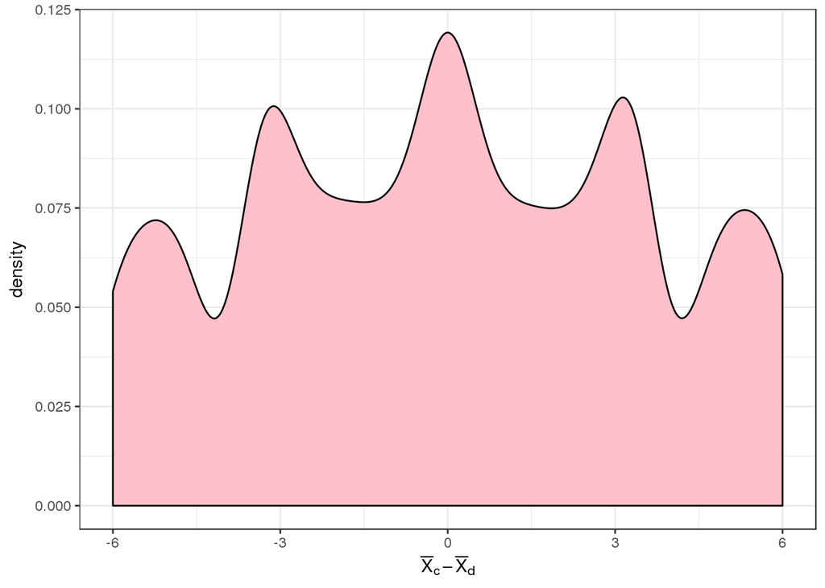

Figure 2.1: Permutation Distribution of $\bar{X}_c - \bar{X}_d$

```r
library(ggplot2)
ggplot(data = data.frame(md = ans), aes(x = md)) +
  geom_density(fill = "pink") +
  theme_bw() +
  labs(x = expression(bar(X)[c]-bar(X)[d]))
```